# Walking Fingerprinting Using Wrist Accelerometry during Activities of Daily Living in NHANES

Lily Koffman

Department of Biostatistics, Johns Hopkins School of Public Health

## Before we get started…

**Join the Mobile and Wearable Data Science ASA Interest Group!** wearableds.github.io/involvement

[figure not shown]

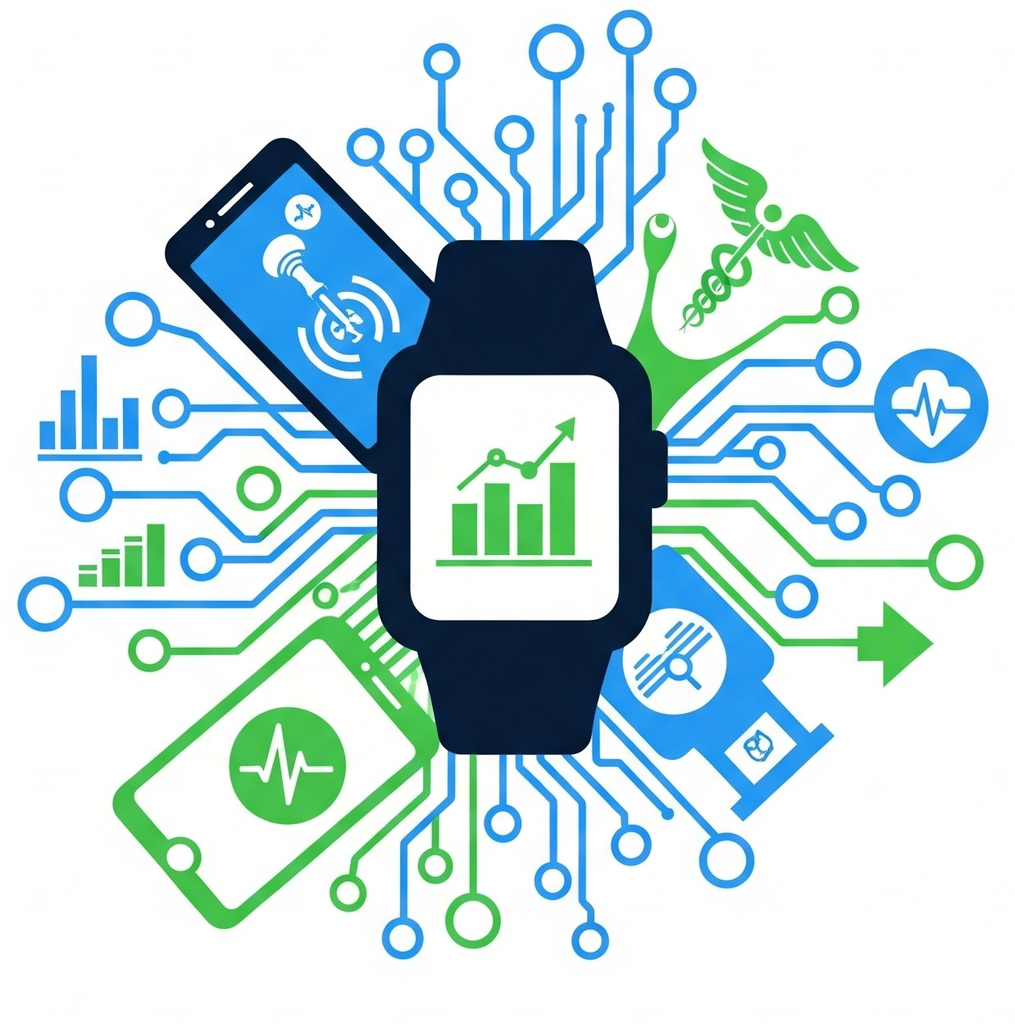

## Introduction: accelerometry data

[figure not shown]

## Introduction: accelerometry data

[figure not shown]

### Problem setup

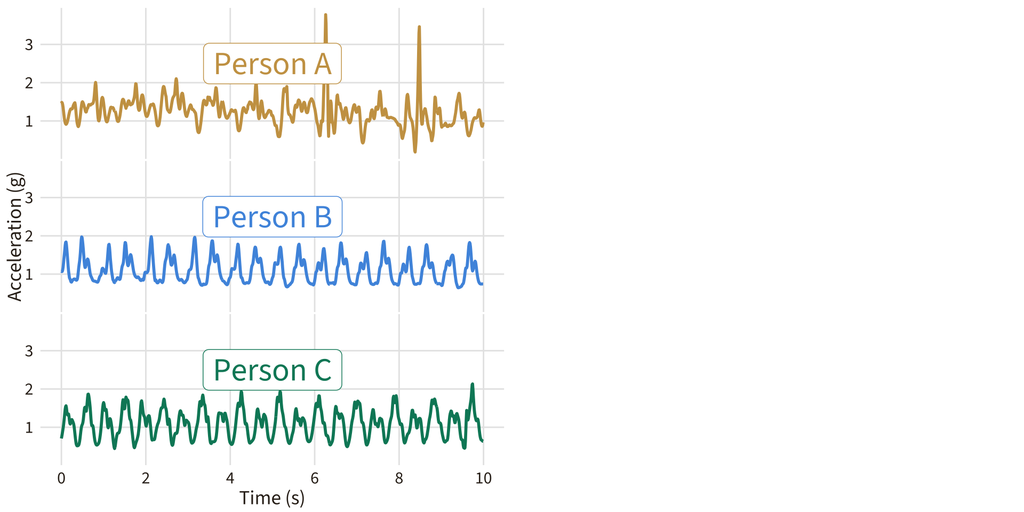

### Problem setup

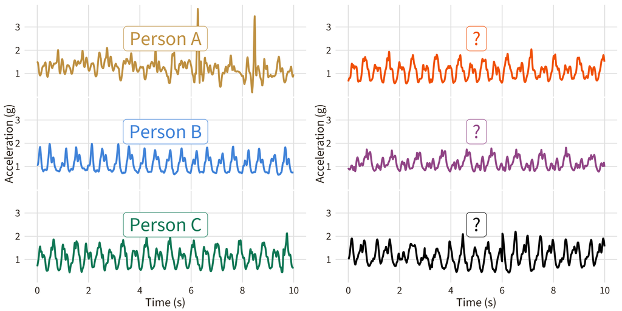

### Problem setup

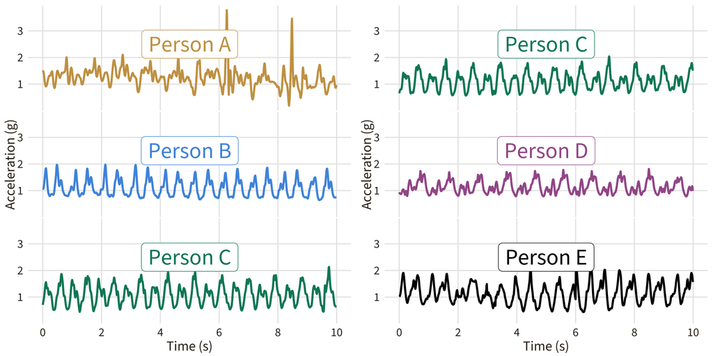

### Big picture method: time series to scalar predictors

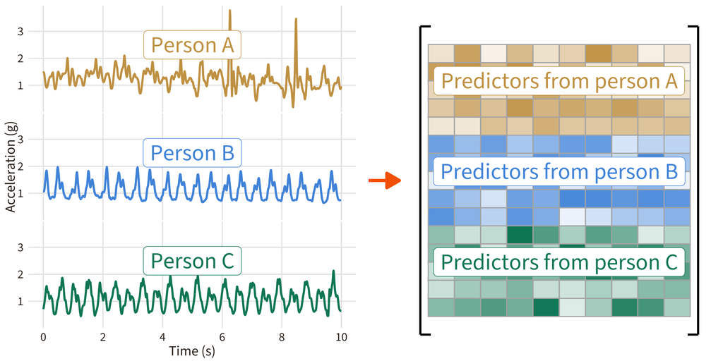

### Model fitting

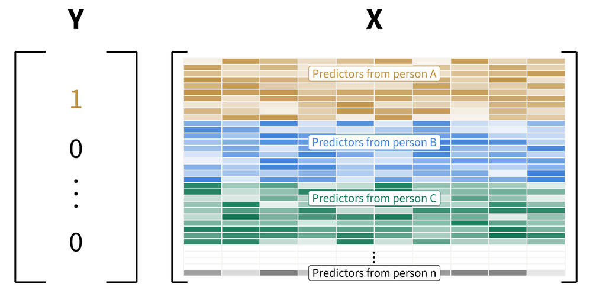

### “Fingerprints” summarize predictors and are different across individuals

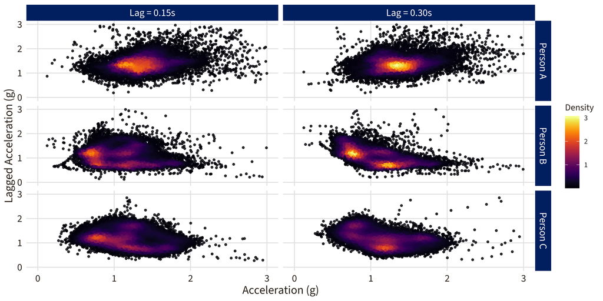

### The method works really well

**32 individuals, 6 minutes of walking each**

100% rank-1 accuracy (Koffman et al. 2023)

### The method works really well

**32 individuals, 6 minutes of walking each**

100% rank-1 accuracy (Koffman et al. 2023)

**153 individuals, 3 minutes of walking each**

93% rank-1 accuracy (Koffman, Crainiceanu, and Leroux 2024)

### The method works really well

**32 individuals, 6 minutes of walking each**

100% rank-1 accuracy (Koffman et al. 2023)

**153 individuals, 3 minutes of walking each**

93% rank-1 accuracy (Koffman, Crainiceanu, and Leroux 2024)

But…we know when people are walking

# Will the method work in a large, unlabeled data set?

### NHANES data

[figure not shown]

## Walking fingerprinting in NHANES

**Process**

- Use algorithm to find walking
- Partition data into train/test
- Fit models

## Walking fingerprinting in NHANES

**Process**

- Use algorithm to find walking
- Partition data into train/test
- Fit models

**Spoiler alert**: the models perform worse (1-41% rank-1 accuracy)

*Why*?

### Walking identification

**ADaptive Empirical Pattern Transformation (ADEPT)** (Karas et al. 2019)

```r
library(adept)
adept::segmentWalking(
  xyz, # data frame of tri-axial accelerometry (3 cols)
  xyz.fs = 100, # sample rate
  template = templates # list of templates for pattern matching
)
```

**stepcount** (Small et al. 2024)

```r
devtools::install_github("jhuwit/stepcount")
library(stepcount)
stepcount::stepcount(file = sample_data, model_type = "ssl")
```

### Walking identification

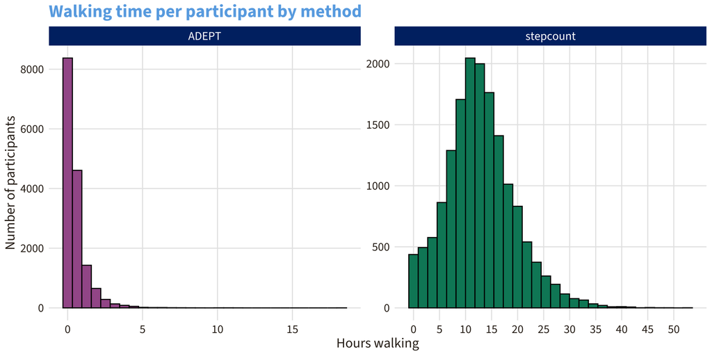

### Walking identification results comparison

More specific algorithm is better

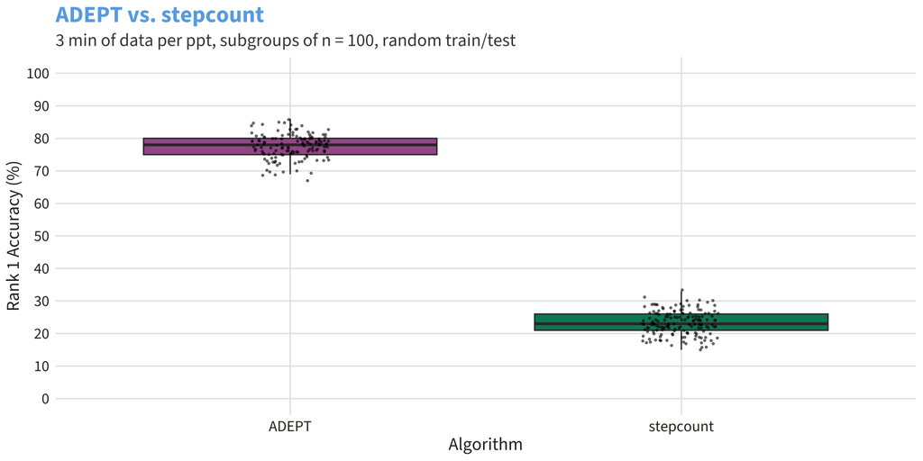

### Partition data into train/test

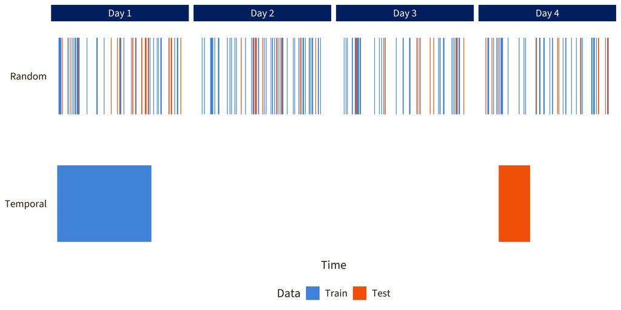

### Train/test partition results comparison

Temporal setting is harder

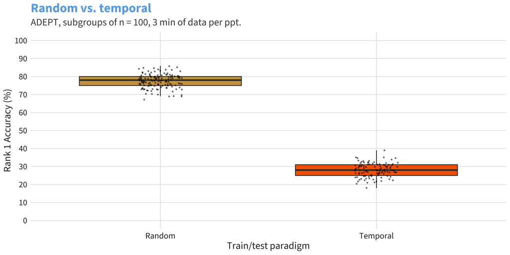

### Sample size

Accuracy $\downarrow$ with increasing sample size

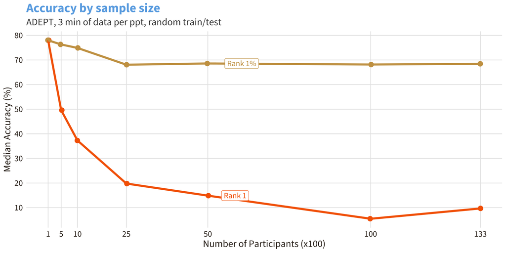

### Amount of training data

More data is better

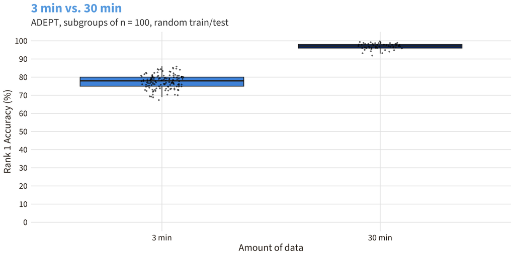

### Model choice

It depends… and computational time is not equal

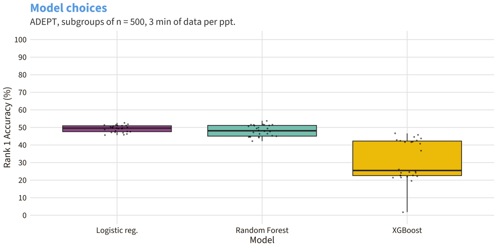

### Model improvements

Rank 1 and rank 1% accuracies of different model types on the entire population

| Dataset | Model | Rank 1 | Rank 1% |
| --- | --- | --- | --- |
| Random (n=13,367) | Logistic | 9.7 | 68 |
|  | Oversampled at 10% | **41** | 68 |
|  | Weighted | 34 | **96** |
|  | Two-stage | 20 | 68 |

### Fingerprints

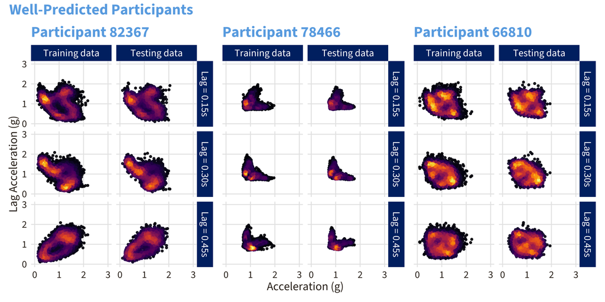

### Fingerprints

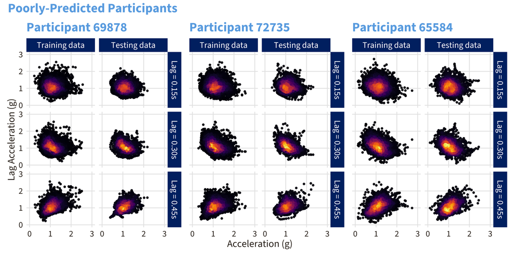

## Summary

- We can identify individuals from their walking patterns in large, unlabeled datasets using predictors derived from acceleration, lag acceleration
- Performance depends on sample size, walking identification algorithm, train/test partition, length of training data, model choice
- Preprint on arXiv (Koffman, Muschelli, and Crainiceanu 2025)
- Next steps: deep learning, using fingerprint as outcome instead of predictor

## Thank you!

- Link to slides: tinyurl.com/koff-enar25
- Email: lkoffma2@jh.edu
- Website: lilykoff.com
- Github: github.com/lilykoff

[figure not shown]

## References

Karas, Marta, Marcin Stra̧czkiewicz, William Fadel, Jaroslaw Harezlak, Ciprian M Crainiceanu, and Jacek K Urbanek. 2019. “Adaptive Empirical Pattern Transformation (ADEPT) with Application to Walking Stride Segmentation.” *Biostatistics* 22 (2): 331–47. https://doi.org/10.1093/biostatistics/kxz033.

Koffman, Lily, Ciprian Crainiceanu, and Andrew Leroux. 2024. “Walking Fingerprinting.” *Journal of the Royal Statistical Society Series C: Applied Statistics* 73 (5): 1221–41. https://doi.org/10.1093/jrsssc/qlae033.

Koffman, Lily, John Muschelli, and Ciprian Crainiceanu. 2025. “Walking Fingerprinting Using Wrist Accelerometry During Activities of Daily Living in NHANES.” https://arxiv.org/abs/2506.17160.

Koffman, Lily, Yan Zhang, Jaroslaw Harezlak, Ciprian Crainiceanu, and Andrew Leroux. 2023. “Fingerprinting Walking Using Wrist-Worn Accelerometers.” *Gait & Posture* 103 (June): 92–98. https://doi.org/10.1016/j.gaitpost.2023.05.001.

Small, Scott R, Shing Chan, Rosemary Walmsley, Lennart von Fritsch, Aidan Acquah, Gert Mertes, Benjamin G Feakins, et al. 2024. “Self-Supervised Machine Learning to Characterize Step Counts from Wrist-Worn Accelerometers in the UK Biobank.” *Medicine and Science in Sports and Exercise* 56 (10): 1945.

[figure not shown]

tinyurl.com/koff-enar25